# filter-puml.tcl documentation

Detlef Groth, Caputh-Schwielowsee, Germany

Nov 30, 2024

filter-abc - filter-cmd - filter-dot - filter-emf - filter-eqn - filter-julia - filter-kroki - filter-mmd - filter-mtex - filter-pic/dpic - filter-pik  
filter-pipe - filter-puml - filter-rplot - filter-sqlite - filter-tcrd - filter-tcl - filter-tdot - filter-tsvg

Documentation: Pantcl filter documentation - Pantcl tutorial - Pantcl Readme - Pantcl Gui

## Name

*filter-puml.tcl* - Filter which can be used to display [PlantUML](https://plantuml.com/) diagram files within a Pandoc processed document using the Tcl filter driver `pantcl.bin`.

## Usage

The conversion of the Markdown documents via Pandoc should be done as follows:

```
pandoc input.md --filter pantcl.bin -s -o output.html
```

The file `filter-puml.tcl` is not used directly but sourced automatically by the `pantcl.bin` file. If code blocks with the `.puml` marker are found, the contents in the code block is processed via the PlantUML command line tool. To install this command line tool you have to download the Java jar file from https://plantuml.com/download an create a shell script which runs the jar file using the Java runtime. Here an example of such a shell script:

```
#!/bin/sh
# file plantuml - adapt the path to the jar file
java -jar /home/username/.local/bin/plantuml-1.2021.16.jar $@
```

If this file is executable and in the PATH the filter should work.

> - app - the application to be called, such as plantuml, so the name of your shell script which must be in the PATH, default: plantuml
> - eval - should the code in the code block be evaluated, default: false
> - ext - file file extension, can be svg, png, pdf, default: png
> - fig - should a figure be created, default: true
> - imagepath - output imagepath, default: images
> - include - should the created image be automatically included, default: true
> - results - should the output of the command line application been shown, should be show or hide, default: hide
> - theme - the image theme which can be used, should be one of the themes listed here: https://the-lum.github.io/puml-themes-gallery/, default: *none*

The options fig, results, include should be normally not used, they are here just for compatibility reasons with the other filters.

To change the defaults the YAML header can be used. Here an example to change the default command line application to plantuml-1.2020 and the image output path to nfigures and the output image format to svg and to evaluate all code chunks in the document - `eval: 1`.

```
 ----
 title: "filter-puml.tcl documentation"
 author: "Detlef Groth, Caputh-Schwielowsee, Germany"
 date: 2021-12-11
 puml:
     app: plantuml-1.2020
     imagepath: nfigures
     ext: svg
     eval: 1
 ----
```

## Examples

Plantuml code must be include as follows:

````
     ```{.puml option=value}
     plantuml code
     ```
````

Here an example for a class diagram:

```
@startuml
abstract        abstract
abstract class  "abstract class"
annotation      annotation
circle          circle
()              circle_short_form
class           class
diamond         diamond
<>              diamond_short_form
entity          entity
enum            enum
interface       interface
@enduml
```

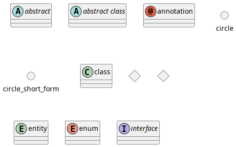

```
@startuml
left to right direction
actor Guest as g
package Professional {
  actor Chef as c
  actor "Food Critic" as fc
}
package Restaurant {
  usecase "Eat Food" as UC1
  usecase "Pay for Food" as UC2
  usecase "Drink" as UC3
  usecase "Review" as UC4
}
fc --> UC4
g --> UC1
g --> UC2
g --> UC3
@enduml
```

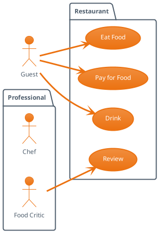

Here an example for a mindmap:

```
@startmindmap
* root node
** first child
*** grand child one
*** grand child two
** second child
@endmindmap
```

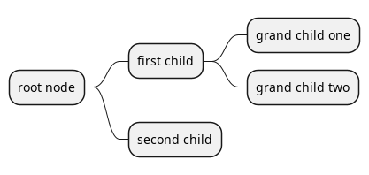

There is as style handwritten which might look useful at some situations. Here an example for a PlantUML mainframe.

```
@startsalt
skinparam handwritten true
mainframe This is a **mainframe**
{+
  Login    | | "MyName   "
  Passwod | | "****     "
  [Cancel] | | [  OK   ]
}
@endsalt
```

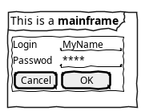

The handwritten style can be applied as well to other diagram types, here a sequence diagram:

```
@startuml
skinparam handwritten true
skinparam monochrome  true
Alice->Bob: Hello Bob, how are you?
Note right of Bob: Bob thinks
Bob-->Alice: I am good thanks!
@enduml
```

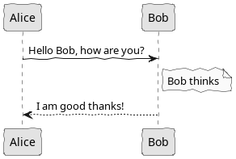

```
@startuml
skinparam handwritten true
skinparam monochrome true
skinparam DefaultFontName xkcd Script
skinparam classFontSize 16
skinparam DefaultTextAlignment center


node Master [
    Master
    Node
]

node Node_1 {
    rectangle container_1
}

node Node_2 {
    rectangle container_64
}

node Node_N {
    rectangle container_N
}

database Metadata [
    Survey
    Metadata
]

database surveys [
    STANDARDIZED
    SURVEY DATA
    ----
    LSST
    ....
    Euclid
    ....
    WFIRST
]

Master -- Node_1
Master -- Node_2
Master -- Node_N

Metadata .. Node_1
Metadata .. Node_2
Metadata .. Node_N

surveys -up-> container_1
surveys -up-> container_64
surveys -up-> container_N
@enduml
```

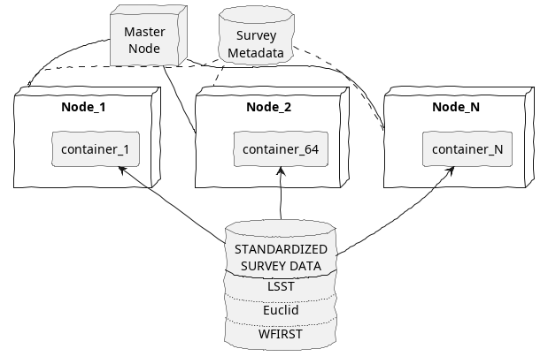

This example needs an installed xkcd-scripts font which can be found for instance here https://github.com/ipython/xkcd-font/blob/master/xkcd-script/font/xkcd-script.ttf. For more themes have a look here: https://the-lum.github.io/puml-themes-gallery/

and for the complete documentation of the different diagram types have a look at the [PDF manual](http://plantuml.com/guide).

Now an even simpler example in case all you want is just a set of nice handwritten buttons:

```
@startuml
<style>
rectangle {
  FontSize 24
  FontStyle bold
  FontColor blue
  FontName Purisa
}
</style>
scale 400 width
skinparam handwritten true
rectangle "  Bob   " #ccddee
rectangle " Alice  " #eeddcc
rectangle " Benny  " #eeeecc
rectangle " <i>E=mc<sup>2</sup></i> " #eeeecc
@enduml
```

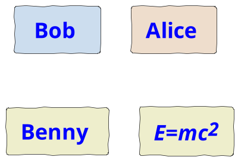

And here a YAML visualization:

```
@startyaml
<style>
yamlDiagram {
  FontSize 24
  FontName Purisa
  FontStyle bold
  node {
    Padding 20
  }
}
</style>
skinparam handwritten true
Key: G
Tempo: "96 BPM"
Capo: "3rd Fret"
@endyaml
```

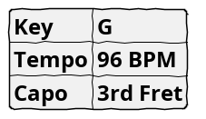

PlantUML supports as well other diagram types, for instance GraphViz diagrams:

```
@startuml
digraph G {
   node[shape=box,style=filled,fillcolor=skyblue];
   rankdir=LR;
   A->B->C;
}
@enduml
```

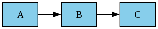

Also Ditaa diagrams are supported:

```
@startditaa
+---------------------------------------------+
| File | Help   cEEE                          |
+---------------+-----------------------------+
|               |                             |
|  tk.Listbox   |         tk.Listbox          |
|               |                             |
|   UniProtIds  |                             |
|               |                             |
|               |      (UniProt-Entry)        |
|              <+>                            |
|               |                             |
|               |                             |
|               |                             |
|               |                             |
|               |                             |
+---------------+---------------------------+-+
|                                             |
|  +--- SeqSearch (labelframe) --------+      |
|  |  /---------\    /-----------\ cFEE|      |
|  |  |ttk.Entry|    | ttk.Button|     |      |
|  |  \---------/    \-----------/     |      |
|  +-----------------------------------+      |
|                                             |
+-------------------------------------------+-+
| ttk.Label (Fileinfo) cEFF| ttk.Progressbar  |
+-------------------------+-------------------+
@endditaa
```

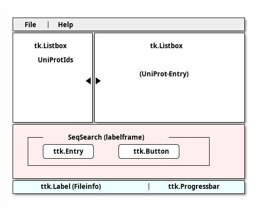

## See also:

- Pantcl Readme
- filter-dot GraphViz Filter
- filter-pik Pikchr Filter
- filter-mmd Mermaid Filter